# Bootstrapping

04/30/2018

## Boostrapping

## Goal of Statistics

- Make inferences about a population based on data.
- How??
  - Traditional statistical inference is based on the assumption of drawing repeated samples from a population
  - A statistic (e.g. the mean or a regression coefficient) is assumed to be fixed in the population.

## What happens?

- If a researcher were to draw multiple samples, the statistic would be different each time.
- The term sampling distribution refers to the distribution that would result from taking multiple samples from a population and re-estimating a statistic on each new set of observations.
- Many times the sampling distribution is assumed to be normal, and a statistic is declared to be “significant” if the 95% confidence interval (the area under the curve excluding the smallest and largest 2.5% of values) does not include zero.

## What if Assumptions are violated?

- Many times we do not have normally distributed variables.
- For example, consider a linear regression, we assume the residuals are normally distributed.
- If we do not have normally distributed residuals then our standard errors are off and therefore our individual significance tests for the estimates in our regression are off.

## In Comes Bootstrapping!

- Bootstrapping is a method of resampling.
- Researchers use this to help us understand the variance of different estimates.

## How does it work?

- We just discussed using a sample to make inferences about a population.
- In Bootstrapping, we will treat our sample data as a population.
- Then we will draw many samples from this new "population."

## How does it work?

- For each sample, we caclulate our test statistic and save the information.
- If we do this say 500 times, we have 500 estimates of our test statistic.

## Example

```r
truth <- function(x){
  2.34 + 2.68*x - 3.42*x^2
}

noise <- function(x){
  rnorm(length(x), sd=0.1)
}
```

## Example Data

```r
set.seed(124)
data <- data_frame(
  x = runif(n=100, min=0, max = 1),
  y = truth(x) + noise(x)
)
```

## Example Data

```r
data %>%
  DT::datatable()
```

|  | x | y |
| --- | --- | --- |
| 1 | 0.0830154397990555 | 2.49270699323396 |
| 2 | 0.408794660819694 | 2.84153304720815 |
| 3 | 0.515284994151443 | 2.72824530612371 |
| 4 | 0.39688234962523 | 2.87224597883287 |
| 5 | 0.222722708247602 | 2.73974273183848 |
| 6 | 0.292349642841145 | 2.79255277433931 |
| 7 | 0.584065895760432 | 2.73400152707463 |
| 8 | 0.490911490749568 | 2.74885362924033 |
| 9 | 0.92299912404269 | 1.81464257885602 |
| 10 | 0.279794845962897 | 2.83398863519112 |

[output cut: 90 more lines]

## Graphing the Data

```r
ggplot(data, aes(x = x, y = y)) +
  stat_function(fun = truth, color = "black", alpha = 0.7, linetype = "dashed") +
  geom_point(alpha = 0.6)
```

## Graphing the Data

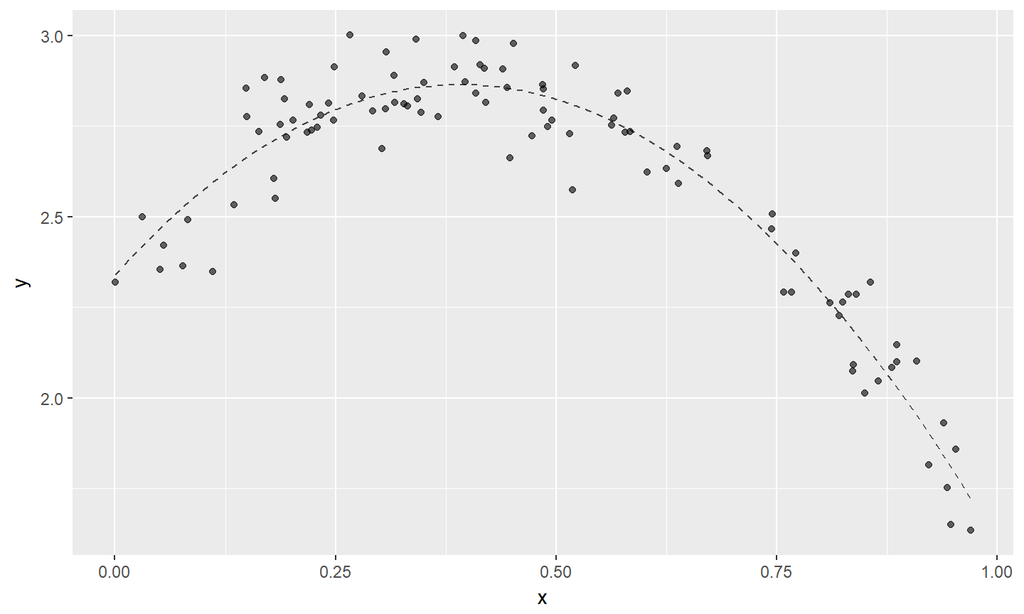

## Our Linear Model

```r
mod <- lm(y~poly(x,2,raw=TRUE), data)
tidy(mod, conf.int=T)[,-c(3:4)]
```

## Our Linear Model

```
##                      term estimate  p.value conf.low conf.high
## 1             (Intercept)     2.32 3.04e-84     2.26      2.39
## 2 poly(x, 2, raw = TRUE)1     2.76 1.10e-32     2.45      3.06
## 3 poly(x, 2, raw = TRUE)2    -3.49 1.58e-42    -3.77     -3.20
```

## Our Linear Model

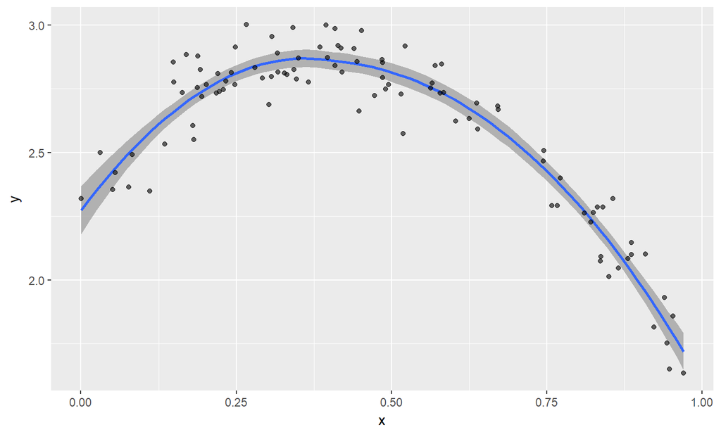

## Bootstrapping

- First we create 10,000 new datasets

```r
data_bootstrap <-
  data %>%
  modelr::bootstrap(10000)
```

## Bootstrapping

|  | strap | .id |
| --- | --- | --- |
| 1 | {'data': {'x': [0.0830154397990555, 0.408794660819694, 0.515284994151443, 0.39688234962523, 0.222722708247602, 0.292349642841145, 0.584065895760432, 0.490911490749568, 0.92299912404269, 0.279794845962… | 00001 |
| 2 | {'data': {'x': [0.0830154397990555, 0.408794660819694, 0.515284994151443, 0.39688234962523, 0.222722708247602, 0.292349642841145, 0.584065895760432, 0.490911490749568, 0.92299912404269, 0.279794845962… | 00002 |
| 3 | {'data': {'x': [0.0830154397990555, 0.408794660819694, 0.515284994151443, 0.39688234962523, 0.222722708247602, 0.292349642841145, 0.584065895760432, 0.490911490749568, 0.92299912404269, 0.279794845962… | 00003 |
| 4 | {'data': {'x': [0.0830154397990555, 0.408794660819694, 0.515284994151443, 0.39688234962523, 0.222722708247602, 0.292349642841145, 0.584065895760432, 0.490911490749568, 0.92299912404269, 0.279794845962… | 00004 |
| 5 | {'data': {'x': [0.0830154397990555, 0.408794660819694, 0.515284994151443, 0.39688234962523, 0.222722708247602, 0.292349642841145, 0.584065895760432, 0.490911490749568, 0.92299912404269, 0.279794845962… | 00005 |
| 6 | {'data': {'x': [0.0830154397990555, 0.408794660819694, 0.515284994151443, 0.39688234962523, 0.222722708247602, 0.292349642841145, 0.584065895760432, 0.490911490749568, 0.92299912404269, 0.279794845962… | 00006 |

## Running the `lm()` on our Bootstrap

- We first need to create a function in which we wish to run on our data.

```r
fn_mod <- function(data){
  lm(y~poly(x, 2, raw=TRUE), data = data)
}
```

## Running the `lm()` on our Bootstrap

- Then we run the `fn_mod()` over out bootstraps

```r
data_bootstrap_model <-
  data_bootstrap %>%
  mutate(model=map(strap, fn_mod))
```

## Running the `lm()` on our Bootstrap

```r
data_bootstrap_model %>%
  head() %>%
  DT::datatable()
```

|  | strap | .id | model |
| --- | --- | --- | --- |
| 1 | {'data': {'x': [0.0830154397990555, 0.408794660819694, 0.515284994151443, 0.39688234962523, 0.222722708247602, 0.292349642841145, 0.584065895760432, 0.490911490749568, 0.92299912404269, 0.279794845962… | 00001 | {'coefficients': [2.39012178930062, 2.47668131375546, -3.22156084596636], 'residuals': [0.180634083085931, 0.0383855629897898, -0.116917992947331, 0.00709167097476338, 0.0511520708681566, 0.0892047652… |
| 2 | {'data': {'x': [0.0830154397990555, 0.408794660819694, 0.515284994151443, 0.39688234962523, 0.222722708247602, 0.292349642841145, 0.584065895760432, 0.490911490749568, 0.92299912404269, 0.279794845962… | 00002 | {'coefficients': [2.30386838623072, 2.94477405501404, -3.69795537014388], 'residuals': [-0.0688144429552408, 0.0893767204218503, -0.0464337519271862, -0.0950666184925007, 0.0129539644212081, -0.056860… |
| 3 | {'data': {'x': [0.0830154397990555, 0.408794660819694, 0.515284994151443, 0.39688234962523, 0.222722708247602, 0.292349642841145, 0.584065895760432, 0.490911490749568, 0.92299912404269, 0.279794845962… | 00003 | {'coefficients': [2.33640081941268, 2.67719590581824, -3.4365747870883], 'residuals': [-0.0640878216278302, -0.0224577268944761, -0.0344647516865334, 0.0214229986263623, 0.192737913505921, -0.02238268… |
| 4 | {'data': {'x': [0.0830154397990555, 0.408794660819694, 0.515284994151443, 0.39688234962523, 0.222722708247602, 0.292349642841145, 0.584065895760432, 0.490911490749568, 0.92299912404269, 0.279794845962… | 00004 | {'coefficients': [2.31968616054047, 2.63042993394454, -3.29080904783922], 'residuals': [-0.174506976611286, -0.222621979920355, -0.138452872528195, -9.87012121309305e-05, 0.0805270043872044, -0.073090… |
| 5 | {'data': {'x': [0.0830154397990555, 0.408794660819694, 0.515284994151443, 0.39688234962523, 0.222722708247602, 0.292349642841145, 0.584065895760432, 0.490911490749568, 0.92299912404269, 0.279794845962… | 00005 | {'coefficients': [2.32027389574876, 2.82528176183716, -3.57931466658802], 'residuals': [-0.0439408939594004, 0.0903270855130547, -0.0957898608377696, 0.0736884576893332, 0.00326354663503583, 0.0185443… |
| 6 | {'data': {'x': [0.0830154397990555, 0.408794660819694, 0.515284994151443, 0.39688234962523, 0.222722708247602, 0.292349642841145, 0.584065895760432, 0.490911490749568, 0.92299912404269, 0.279794845962… | 00006 | {'coefficients': [2.29854160922423, 2.8688739565782, -3.60961092562243], 'residuals': [-0.0396261326287776, -0.0462956225851012, -0.089848582527923, 0.128926477577972, 0.0243668153164693, 0.1002879192… |

## Getting the Parameters

- We use the `tidy()` function from the `broom` package.

```r
data_bootstrap_param <-
  data_bootstrap_model %>%
  mutate(param = map(model, tidy)) %>%
  select(.id, param) %>%
  unnest()
```

## Getting the Parameters

```r
data_bootstrap_param %>%
  head() %>%
  DT::datatable()
```

|  | .id | term | estimate | std.error | statistic | p.value |
| --- | --- | --- | --- | --- | --- | --- |
| 1 | 00001 | (Intercept) | 2.39012178930062 | 0.0371826299820924 | 64.2806006582035 | 2.50203776389026e-81 |
| 2 | 00001 | poly(x, 2, raw = TRUE)1 | 2.47668131375546 | 0.177500020427133 | 13.9531325562421 | 6.35046471404864e-25 |
| 3 | 00001 | poly(x, 2, raw = TRUE)2 | -3.22156084596636 | 0.168541598052562 | -19.1143366574801 | 1.15982273342521e-34 |
| 4 | 00002 | (Intercept) | 2.30386838623072 | 0.0336765578170282 | 68.4116351424071 | 6.76907087959256e-84 |
| 5 | 00002 | poly(x, 2, raw = TRUE)1 | 2.94477405501404 | 0.150398396856775 | 19.5798234326817 | 1.80855762724377e-35 |
| 6 | 00002 | poly(x, 2, raw = TRUE)2 | -3.69795537014388 | 0.137739046103648 | -26.8475459555687 | 1.07040065499199e-46 |

## Distribution Plots

```r
data_bootstrap_param %>%
  ggplot(aes(x = estimate)) +
  geom_histogram(binwidth = 0.05) +
  facet_grid(term ~ ., scales = "free_x")
```

## Distribution Plots

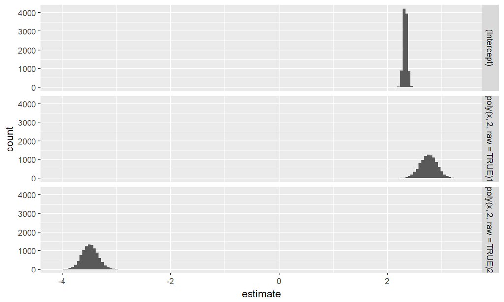

## Summarizing the Results

```r
data_bootstrap_param_mean <-
  data_bootstrap_param %>%
  group_by(term) %>%
  summarise(estimate_mean = mean(estimate))
```

## Summarizing the Results

```r
data_bootstrap_param_mean %>%
  DT::datatable()
```

|  | term | estimate_mean |
| --- | --- | --- |
| 1 | (Intercept) | 2.32470949341213 |
| 2 | poly(x, 2, raw = TRUE)1 | 2.75245268430527 |
| 3 | poly(x, 2, raw = TRUE)2 | -3.48191932215691 |

## Interquartile Range of Estimates

```r
data_bootstrap_param %>%
  group_by(term) %>%
  summarise(
    q_25 = quantile(estimate, 0.25),
    median = quantile(estimate, 0.50),
    q_75 = quantile(estimate, 0.75)
  )
```

## Interquartile Range of Estimates

```
## # A tibble: 3 x 4
##   term                     q_25 median  q_75
##   <chr>                   <dbl>  <dbl> <dbl>
## 1 (Intercept)              2.30   2.32  2.35
## 2 poly(x, 2, raw = TRUE)1  2.65   2.76  2.86
## 3 poly(x, 2, raw = TRUE)2 -3.58  -3.48 -3.38
```

## Confidence Intervals

```r
data_bootstrap_param %>%
  group_by(term) %>%
  summarise(
    lower_95 = quantile(estimate, 0.025),
    upper_95 = quantile(estimate, 0.975)
  )
```

## Confidence Intervals

```
## # A tibble: 3 x 3
##   term                    lower_95 upper_95
##   <chr>                      <dbl>    <dbl>
## 1 (Intercept)                 2.25     2.40
## 2 poly(x, 2, raw = TRUE)1     2.42     3.06
## 3 poly(x, 2, raw = TRUE)2    -3.77    -3.18
```

## Add Predictions to Plot of Original Data

```r
grid <-
  data %>%
  expand(x=seq_range(x,20))

boot_pred <-
  data_bootstrap_model %>%
  transmute(
    .id,
    data = map2(list(grid), model, add_predictions, var = "y")
  ) %>%
  unnest()
```

## Add Predictions to Plot of Original Data

|  | x |
| --- | --- |
| 1 | 0.000450939871370792 |
| 2 | 0.0514784060712708 |
| 3 | 0.102505872271171 |
| 4 | 0.153533338471071 |
| 5 | 0.204560804670971 |
| 6 | 0.255588270870871 |

## Add Predictions to Plot of Original Data

|  | .id | x | y |
| --- | --- | --- | --- |
| 1 | 00001 | 0.000450939871370792 | 2.39123796855969 |
| 2 | 00001 | 0.0514784060712708 | 2.50908017473733 |
| 3 | 00001 | 0.102505872271171 | 2.61014576579064 |
| 4 | 00001 | 0.153533338471071 | 2.69443474171962 |
| 5 | 00001 | 0.204560804670971 | 2.76194710252427 |
| 6 | 00001 | 0.255588270870871 | 2.81268284820458 |

## Plot Data and Model Estimates

```r
ggplot(data = data, mapping = aes(x = x, y = y)) +
  geom_line(
    data = boot_pred %>% filter(as.numeric(.id) < 3000),
    aes(group = .id),
    color = "blue",
    alpha = 0.002
  ) +
  stat_function(fun = truth, color = "black", linetype = "dashed", size = 1) +
  geom_point(data = data, alpha = 0.5)
```

## Plot Data and Model Estimates

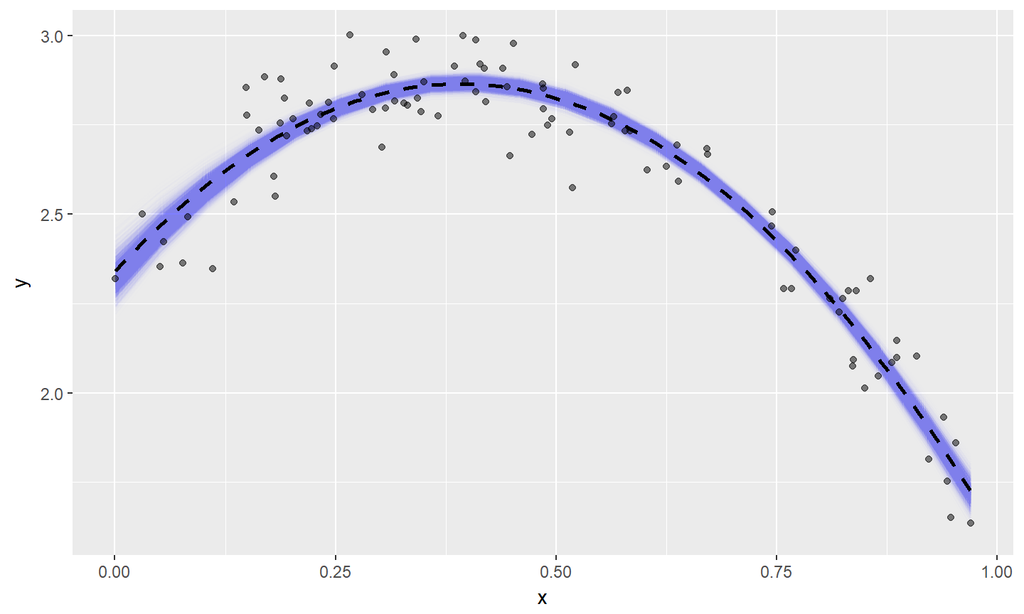